# Classification

## Logistic Regression

### Question (b)

Use the full data set to perform a logistic regression with `Direction` as the response and the five lag variables plus `Volume` as predictors. Use the summary function to print the results. Do any of the predictors appear to be statistically significant? If so, which ones?

```r
glm.fit <- glm(Direction ~ Lag1 + Lag2 + Lag3 + Lag4 + Lag5 + Volume, data = Weekly, family = binomial(link="logit"))
```

```r
summary(glm.fit)$coef %>%
  round(3) %>%
  kbl() %>%
  kable_styling(bootstrap_options = c("striped", "hover", "condensed"))
```

|  | Estimate | Std. Error | z value | Pr(>\|z\|) |
| --- | --- | --- | --- | --- |
| (Intercept) | 0.267 | 0.086 | 3.106 | 0.002 |
| Lag1 | -0.041 | 0.026 | -1.563 | 0.118 |
| Lag2 | 0.058 | 0.027 | 2.175 | 0.030 |
| Lag3 | -0.016 | 0.027 | -0.602 | 0.547 |
| Lag4 | -0.028 | 0.026 | -1.050 | 0.294 |
| Lag5 | -0.014 | 0.026 | -0.549 | 0.583 |
| Volume | -0.023 | 0.037 | -0.616 | 0.538 |

The variable `Lag2` appears to have some statistical significance with 3% of significance.

### Question (c)

Compute the **confusion matrix** and overall fraction of correct predictions. Explain what the confusion matrix is telling you about the types of mistakes made by logistic regression.

```r
# Predicted x'beta
xb <- predict(glm.fit, type = "link", newdata = Weekly)
# Predicted probability
prob <- predict(glm.fit, type = "response", newdata = Weekly)
```

```r
pred_Weekly <- cbind(Weekly, xb, prob)
pred_Weekly$Prediction <- rep("Down", 1089)
pred_Weekly$Prediction[prob > 0.5] <- "Up"
```

```r
cm <- confusionMatrix(factor(pred_Weekly$Prediction),
                      factor(pred_Weekly$Direction),
                      dnn = c("Prediction", "Direction"))
```

Let’s build our confusion matrix in a visual way:

```r
plt <- as.data.frame(cm$table)

plotTable <- plt %>%
  mutate(Correct = ifelse(plt$Prediction == plt$Direction, "TRUE", "FALSE")) %>%
  group_by(Direction) %>%
  mutate(prop = Freq/sum(Freq))
```

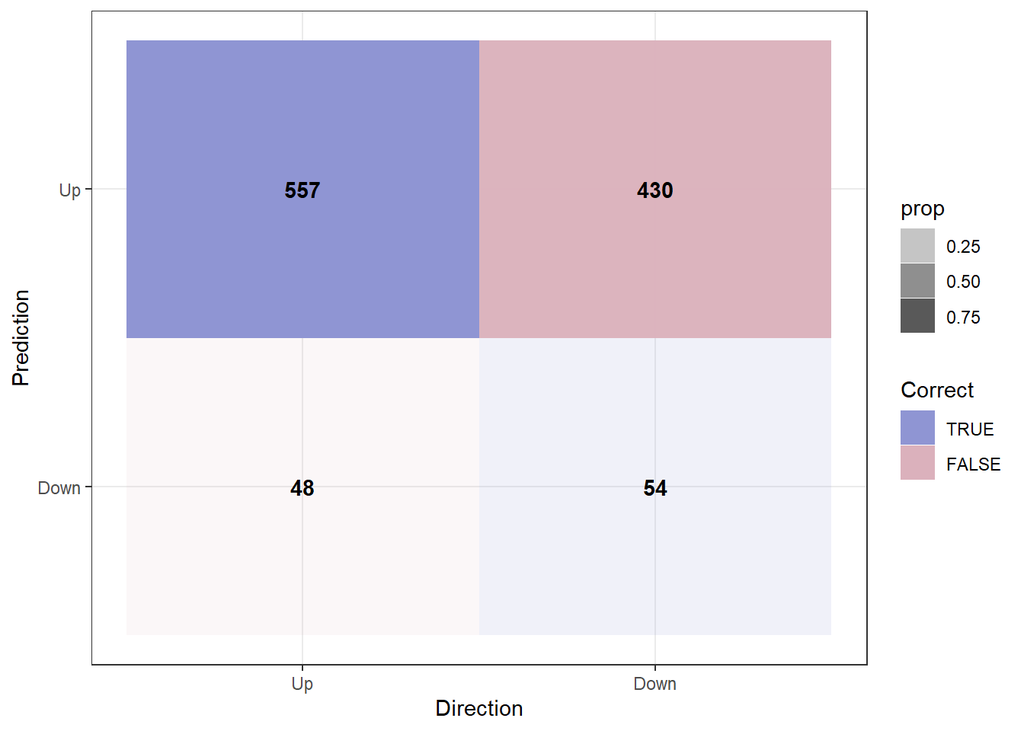

Figure 9: Confusion Matrix: Logistic Regression

```r
ggplot(plotTable, aes(x = Direction, y = Prediction, fill = Correct, alpha = prop)) +
  geom_tile() +
  geom_text(aes(label = Freq), vjust = .5, fontface  = "bold", alpha = 1) +
  scale_fill_manual(values = c("TRUE" = "#8F95D3", "FALSE" = "#DBB1BC")) +
  theme_bw() +
  xlim(rev(levels(plt$Direction)))
```

**Accuracy**:

```
Accuracy
   0.561
```

### Question (d)

Now fit the logistic regression model using a training data period *from 1990 to 2008*, with `Lag2` as the only predictor. Compute the confusion matrix and the overall fraction of correct predictions for the held out data (that is, the data from 2009 and 2010).

```r
Weekly_train <- Weekly %>%
  filter(Year <= 2008)
Weekly_test <- Weekly %>%
  filter(Year > 2008)
```

```r
glm_fit <- glm(Direction ~ Lag2,
               data = Weekly_train,
               family = binomial)
```

```r
prob <- predict(glm_fit, type = "response", newdata = Weekly_test)
pred_Weekly_test <- cbind(Weekly_test, prob)
pred_Weekly_test$Prediction <- rep("Down", nrow(Weekly_test))
pred_Weekly_test$Prediction[prob > 0.5] <- "Up"
```

```r
cm <- confusionMatrix(factor(pred_Weekly_test$Prediction),
                      factor(pred_Weekly_test$Direction),
                      dnn = c("Prediction", "Direction"))

plt <- as.data.frame(cm$table)

plotTable <- plt %>%
  mutate(Correct = ifelse(plt$Prediction == plt$Direction, "TRUE", "FALSE")) %>%
  group_by(Direction) %>%
  mutate(prop = Freq/sum(Freq))
```

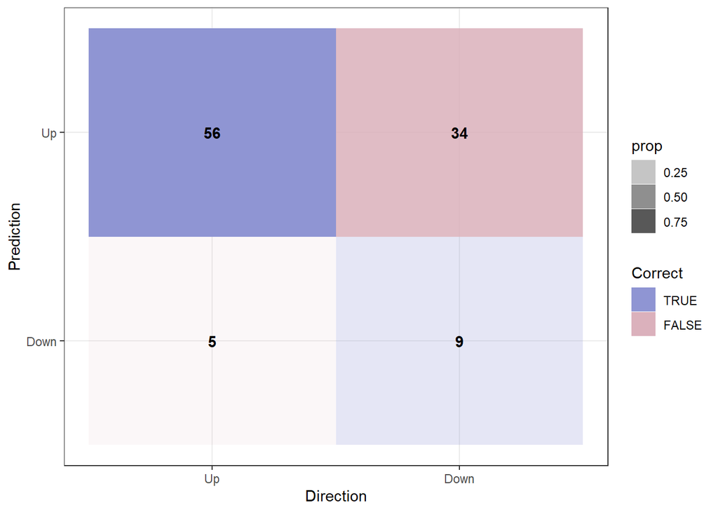

Figure 10: Confusion Matrix on Test Data: Logistic Regression

```r
ggplot(plotTable, aes(x = Direction, y = Prediction, fill = Correct, alpha = prop)) +
  geom_tile() +
  geom_text(aes(label = Freq), vjust = .5, fontface  = "bold", alpha = 1) +
  scale_fill_manual(values = c("TRUE" = "#8F95D3", "FALSE" = "#DBB1BC")) +
  theme_bw() +
  xlim(rev(levels(plt$Direction)))
```

```
Accuracy
   0.625
```

## LDA, QDA, KNN & Naive Bayes

### Question (e) to (h)

**LDA:**

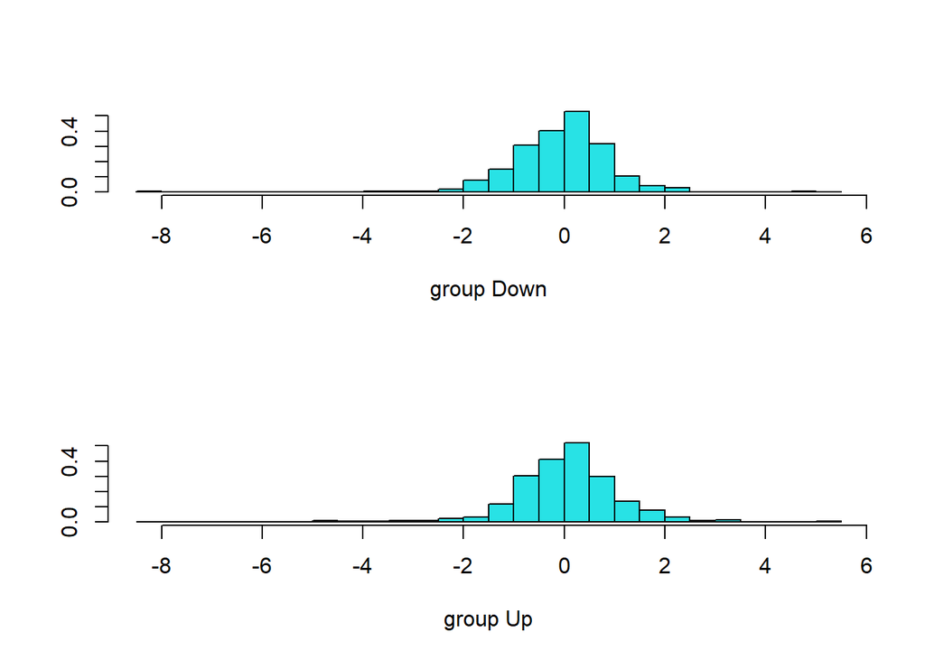

```r
lda.fit <- MASS::lda(Direction ~ Lag2, data = Weekly_train)
plot(lda.fit)
```

Predictions are done using the test data:

```r
prediction_lda <- predict(lda.fit, newdata = Weekly_test)
lda_Weekly <- cbind(Weekly_test, Prediction = prediction_lda$class)
```

```r
cm <- confusionMatrix(factor(lda_Weekly$Prediction),
                      factor(lda_Weekly$Direction),
                      dnn = c("Prediction", "Direction"))
plt <- as.data.frame(cm$table)
plotTable <- plt %>%
  mutate(Correct = ifelse(plt$Prediction == plt$Direction, "TRUE", "FALSE")) %>%
  group_by(Direction) %>%
  mutate(prop = Freq/sum(Freq))
```

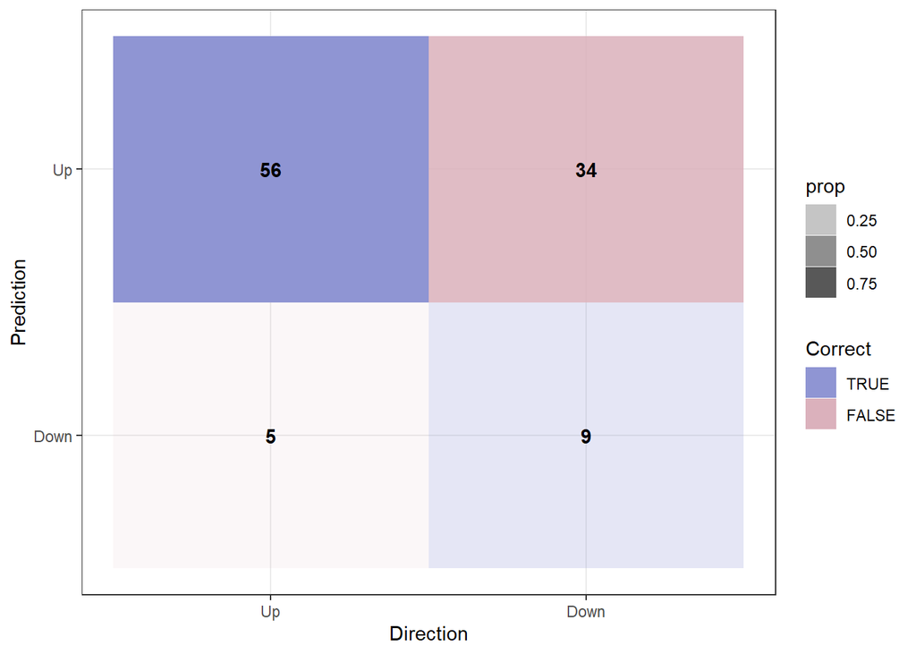

Figure 11: Confusion Matrix: Linear Discriminant Analysis

```r
ggplot(plotTable, aes(x = Direction, y = Prediction, fill = Correct, alpha = prop)) +
  geom_tile() +
  geom_text(aes(label = Freq), vjust = .5, fontface  = "bold", alpha = 1) +
  scale_fill_manual(values = c("TRUE" = "#8F95D3", "FALSE" = "#DBB1BC")) +
  theme_bw() +
  xlim(rev(levels(plt$Direction)))
```

```
Accuracy: 0.625
```

**QDA**:

We will now fit a QDA model:

```r
qda.fit <- MASS::qda(Direction ~ Lag2, data = Weekly_train)
```

```r
prediction_qda <- predict(qda.fit, newdata = Weekly_test)
qda_Weekly <- cbind(Weekly_test, Prediction = prediction_qda$class)
```

```r
cm <- confusionMatrix(factor(qda_Weekly$Prediction),
                      factor(qda_Weekly$Direction),
                      dnn = c("Prediction", "Direction"))
plt <- as.data.frame(cm$table)
plotTable <- plt %>%
  mutate(Correct = ifelse(plt$Prediction == plt$Direction, "TRUE", "FALSE")) %>%
  group_by(Direction) %>%
  mutate(prop = Freq/sum(Freq))
```

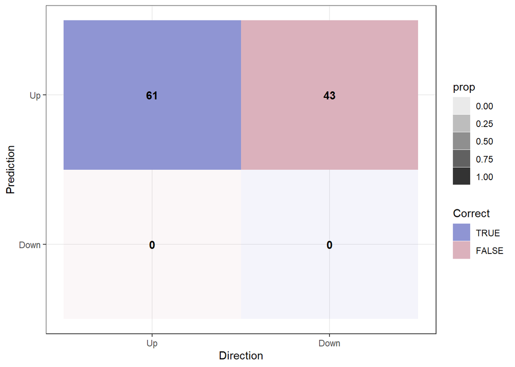

Figure 12: Confusion Matrix: Quadratic Discriminant Analysis

```r
ggplot(plotTable, aes(x = Direction, y = Prediction, fill = Correct, alpha = prop)) +
  geom_tile() +
  geom_text(aes(label = Freq), vjust = .5, fontface  = "bold", alpha = 1) +
  scale_fill_manual(values = c("TRUE" = "#8F95D3", "FALSE" = "#DBB1BC")) +
  theme_bw() +
  xlim(rev(levels(plt$Direction)))
```

```
Accuracy: 0.587
```

**KNN** (`k=1`):

We will now perform KNN using the `knn()` function, which is part of the `class` library. First we need to re-arrange our train and test data:

```r
train_x <-  Weekly_train %>%
  dplyr::select(Lag2)

test_x <- Weekly_test %>%
  dplyr::select(Lag2)

train_y <- Weekly_train %>%
  dplyr::select(Direction)
```

```r
set.seed(1)
knn_pred <- knn(as.matrix(train_x),
                as.matrix(test_x),
                as.matrix(train_y),
                k = 1)
```

```r
table(knn_pred, Weekly_test[["Direction"]])
```

```
knn_pred Down Up
    Down   21 30
    Up     22 31
```

```
Accuracy: 0.5
```

It appears that this model is not performing that well.

**Naive Bayes**:

```r
nbayes.fit <- naiveBayes(Direction ~ Lag2, data = Weekly_train)
```

```r
prediction_nbayes <- predict(nbayes.fit , newdata = Weekly_test)
nbayes_Weekly <- cbind(Weekly_test, Prediction = prediction_nbayes)
```

```r
cm <- confusionMatrix(factor(nbayes_Weekly$Prediction),
                      factor(nbayes_Weekly$Direction),
                      dnn = c("Prediction", "Direction"))
plt <- as.data.frame(cm$table)
plotTable <- plt %>%
  mutate(Correct = ifelse(plt$Prediction == plt$Direction, "TRUE", "FALSE")) %>%
  group_by(Direction) %>%
  mutate(prop = Freq/sum(Freq))
```

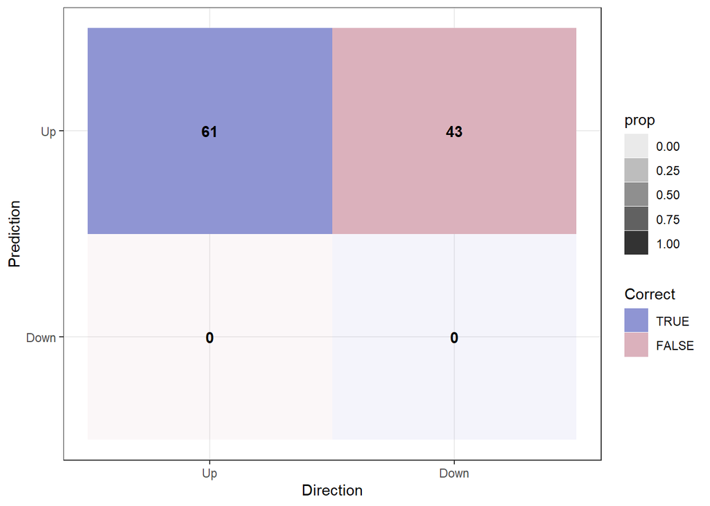

```r
ggplot(plotTable, aes(x = Direction, y = Prediction, fill = Correct, alpha = prop)) +
  geom_tile() +
  geom_text(aes(label = Freq), vjust = .5, fontface  = "bold", alpha = 1) +
  scale_fill_manual(values = c("TRUE" = "#8F95D3", "FALSE" = "#DBB1BC")) +
  theme_bw() +
  xlim(rev(levels(plt$Direction)))
```

```
Accuracy: 0.587
```

## Model Comparison

### Question (i)

*Which of these methods appears to provide the best results on this data?*

The two best models are Logit and LDA. The accuracy of the Naive Bayes is very similar to that of the QDA model, being both the second best option.

# DSM: KNN, Logit & LDA

In this question you will produce a picture like Figure 2.2 in the book Elements of Statistical Learning on pp.15, but for a different dataset. Try to understand first the code for this Figure by running the posted file `mixture.R`, where the generated dataset for Figure 2.2 and the code is given.

### Question 1

Generate a dataset consisting of `n = 100` observations from the logit model below:

$$\Pr(y=1|x)=\frac{1}{1+\exp(-\beta_1x_1-\beta_2x_2)}$$
with $x_1\sim_{\text{iid }} N(0,1)$, $x_2\sim_{\text{idd}} N(0,4)$, $\beta_1=2$ and $\beta_2=3$. Here $x_1 \perp x_2$ but you don’t need to impose this in the analysis.

```r
n <- 100
set.seed(666)

# Covariates
x1 <- rnorm(n, mean = 0, sd = 1)
x2 <- rnorm(n, mean = 0, sd = 2)

# Coefficients
b1 <- 2
b2 <- 3

# Single Index
z <- b1*x1 + b2*x2

# Logit Model
pr <- 1/(1+exp(-z))
```

We can now generate our dependent variable:

```r
y <- as.factor(rbinom(n,1,pr))
```

We generate a `dataframe`:

```r
data <- data.frame(cbind(y, x1, x2))
```

### Question 2

Plot the data in the two dimensions $x_1$ and $x_2$, using orange and blue circles for the two classes in $y$.

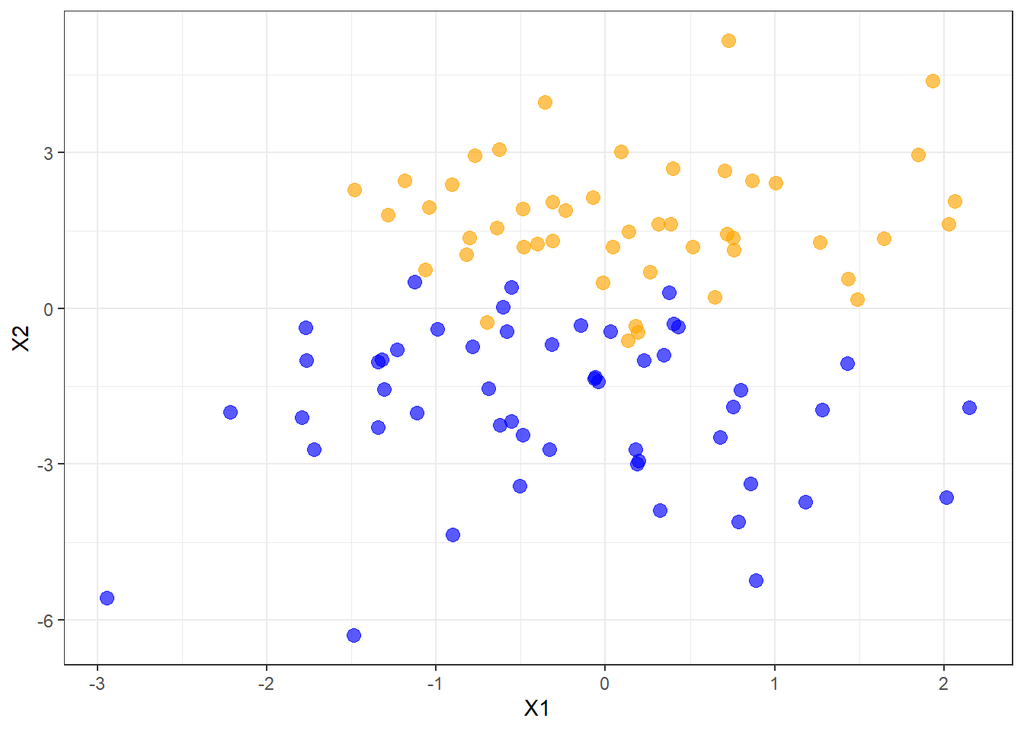

Figure 14: Basic Scatterplot

```r
data %>%
  ggplot(aes(x = x1, y = x2, color = as.factor(y))) +
  geom_point(size = 3, alpha = 0.65) +
  theme_bw() + xlab("X1") + ylab("X2") +
  scale_color_manual(values = c("blue", "orange")) +
  theme(legend.position="none")
```

### Question 3

The Bayes decision boundary are the points $x_1$ and $x_2$ such that $\Pr(y = 1 | x) = 0.5$.

For each $x_1$ in the simulated (or training) data, calculate $x_2$ such that $\Pr(y = 1 | x) = 0.5$ and add the Bayes decision boundary on the plot in b) using a dashed purple line. Is this boundary linear and can you find the exact formula for it? Explain.

We have that:

which means that the odds ratio is $1$. This implies that $z=\beta_1x_1+\beta_2x_2=0$. Finally, we can get the relationship between the covariates, which is defined by a **straight line**:

Let’s generate our data now:

```r
data <- cbind(data, bayes = -b1*x1/b2)
```

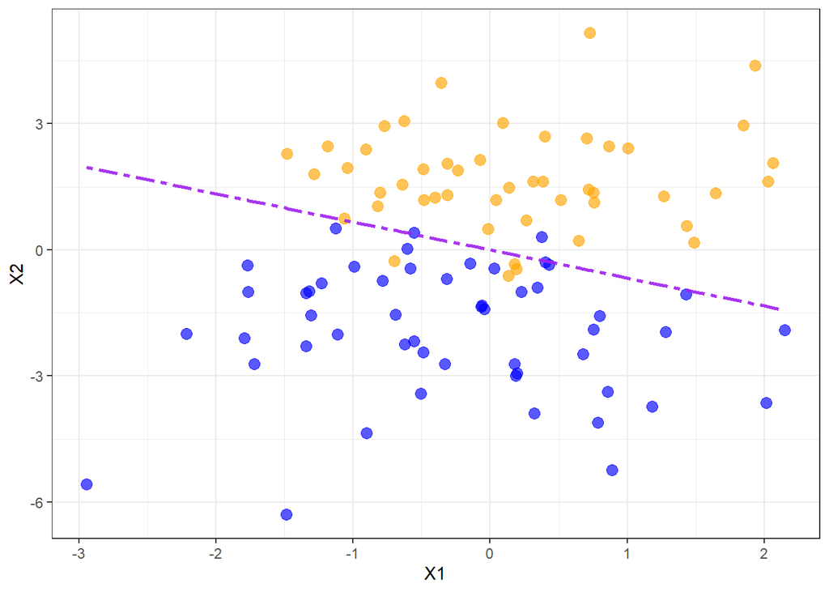

Figure 15: Linear Bayes Decision Boundary

```r
data %>%
  ggplot(aes(x = x1)) +
  geom_point(aes(y = x2, color = as.factor(y)), size = 3, alpha = 0.65) +
  geom_line(aes(y = bayes), size = 1, color = "purple", linetype = 6, alpha = 0.9) +
  theme_bw() + xlab("X1") + ylab("X2") +
  scale_color_manual(values = c("blue", "orange")) +
  theme(legend.position="none")
```

### Question 4

Construct a test set on a grid of `g = 50` values for $x_1$ and $x_2$, ranging from their minimum to their maximum. Generate a test set from each combination of $x_1$ and $x_2$, and call it test. Gather the training set for $x$ into a data frame called train.

Let’s start with our **train data**:

```r
train <- data.frame(cbind(y, x1, x2))
```

Now our **test data**:

```r
g <- 50

x1_test <- seq(min(x1), max(x1), length.out = g)
x2_test <- seq(min(x2), max(x2), length.out = g)

test <- expand.grid(x1_test, x2_test)
```

### Question 5

Run a KNN analysis with `k = 3` nearest neighbors on the test data using the training data and the realizations of $y$. Use the command `knn()`.

Let’s scale our covariates first:

```r
s.train <- scale(train[,2:3])
s.test <- scale(test)
```

We run our `knn()`:

```r
knn.fit3 <- knn(s.train, s.test, y, k=3, prob = TRUE)
```

### Question 6

Following the `mixture.R` code, plot the training data with circles, the test data with dots, each with the color blue or orange according to which class they either belong to (in the training data) or to which class they were assigned to (in the test data). Add the **KNN decision boundary** to the plot using `contour()` and the Bayes decision boundary.

```r
prob3 <- attr(knn.fit3, "prob")
prob3 <- ifelse(knn.fit3=="1", prob3, 1-prob3) # if class =1 return the prob of 1
probm3 <- matrix(prob3, g, g)
```

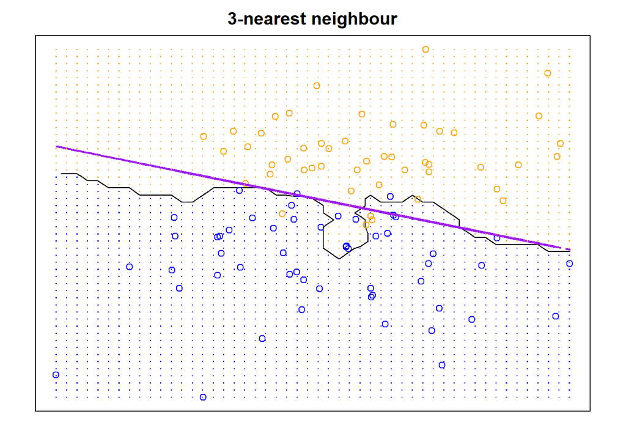

Figure 16: KNN Bayes Decision Boundary

```r
par(mar=rep(2,4))
contour(x1_test, x2_test, probm3, levels=0.5, labels="", xlab="X1", ylab="X2", main=
"3-nearest neighbour", axes=FALSE)
points(train[,2:3], col=ifelse(y==1, "orange", "blue"))
lines(data[,c("x1", "bayes")], type="l", lty=2, lwd=2, col="purple")
points(test, pch=".", cex=1.2, col=ifelse(probm3>0.5, "orange", "blue"))
box()
```

### Question 7

Repeat e) and f) with `k = 10` and `k = 15`. Calculate the test error rate for each of `k = 3`; `10`; `15`, and the Bayes decision boundary. Which `k` gets closest to the Bayes decision boundary? Explain why this makes sense or not.

**Case**: `k=10`:

```r
knn.fit10 <- knn(s.train, s.test, y, k=10, prob = TRUE)

prob10 <- attr(knn.fit10, "prob")
prob10 <- ifelse(knn.fit10=="1", prob10, 1-prob10) # if class =1 return the prob of 1
probm10 <- matrix(prob10, g, g)
```

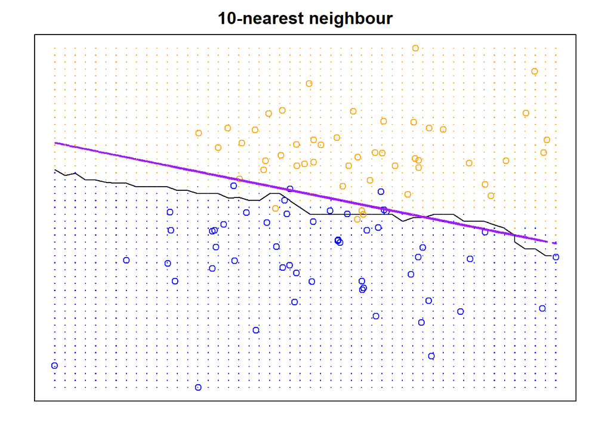

Figure 17: KNN Bayes Decision Boundary

```r
par(mar=rep(2,4))
contour(x1_test, x2_test, probm10, levels=0.5, labels="", xlab="X1", ylab="X2", main=
"10-nearest neighbour", axes=FALSE)
points(train[,2:3], col=ifelse(y==1, "orange", "blue"))
lines(data[,c("x1", "bayes")], type="l", lty=2, lwd=2, col="purple")
points(test, pch=".", cex=1.2, col=ifelse(probm10>0.5, "orange", "blue"))
box()
```

**Case**: `k=15`:

```r
knn.fit15 <- knn(s.train, s.test, y, k=15, prob = TRUE)

prob15 <- attr(knn.fit15, "prob")
prob15 <- ifelse(knn.fit15=="1", prob15, 1-prob15) # if class =1 return the prob of 1
probm15 <- matrix(prob15, g, g)
```

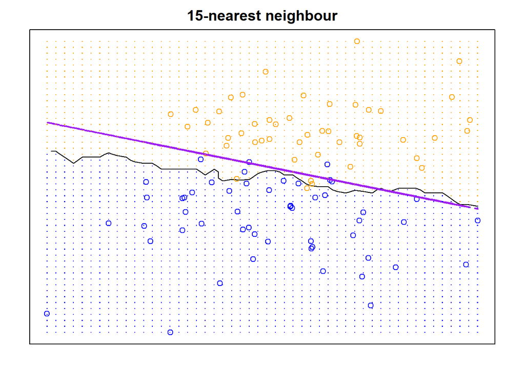

Figure 18: KNN Bayes Decision Boundary

```r
par(mar=rep(2,4))
contour(x1_test, x2_test, probm15, levels=0.5, labels="", xlab="X1", ylab="X2", main=
"15-nearest neighbour", axes=FALSE)
points(train[,2:3], col=ifelse(y==1, "orange", "blue"))
lines(data[,c("x1", "bayes")], type="l", lty=2, lwd=2, col="purple")
points(test, pch=".", cex=1.2, col=ifelse(probm15>0.5, "orange", "blue"))
box()
```

Finally, we can get the **test error rate**:

```r
# Generate the true classes for test data
z.test = b1*test[,1] + b2*test[,2]
pr.test = 1/(1+exp(-z.test))
y.test = as.factor(rbinom(length(pr.test),1,pr.test))
```

```r
table(knn.fit3,y.test)
```

```
        y.test
knn.fit3    0    1
       0 1318   35
       1  115 1032
```

```
Test Error Rate (k=3): 0.06
```

```r
table(knn.fit10,y.test)
```

```
         y.test
knn.fit10    0    1
        0 1324   20
        1  109 1047
```

```
Test Error Rate (k=10): 0.0516
```

```r
table(knn.fit15,y.test)
```

```
         y.test
knn.fit15    0    1
        0 1311   21
        1  122 1046
```

```
Test Error Rate (k=15): 0.0572
```